# TO_628_NOTE_1

Ella.Li

3/8/2022

# Just starting

We are starting right now. **wish us luck!**

```r
# Just writing some code
print('Hello World!')
```

```
## [1] "Hello World!"
```

## Import data

we will start import data

```r
# import data
nyc <- read.csv("nycflights.csv")

# look structure
str(nyc)
```

```
## 'data.frame':    336776 obs. of  20 variables:
##  $ X             : int  1 2 3 4 5 6 7 8 9 10 ...
##  $ year          : int  2013 2013 2013 2013 2013 2013 2013 2013 2013 2013 ...
##  $ month         : int  1 1 1 1 1 1 1 1 1 1 ...
##  $ day           : int  1 1 1 1 1 1 1 1 1 1 ...
##  $ dep_time      : int  517 533 542 544 554 554 555 557 557 558 ...
##  $ sched_dep_time: int  515 529 540 545 600 558 600 600 600 600 ...
##  $ dep_delay     : int  2 4 2 -1 -6 -4 -5 -3 -3 -2 ...
##  $ arr_time      : int  830 850 923 1004 812 740 913 709 838 753 ...
##  $ sched_arr_time: int  819 830 850 1022 837 728 854 723 846 745 ...
##  $ arr_delay     : int  11 20 33 -18 -25 12 19 -14 -8 8 ...
##  $ carrier       : chr  "UA" "UA" "AA" "B6" ...
##  $ flight        : int  1545 1714 1141 725 461 1696 507 5708 79 301 ...
##  $ tailnum       : chr  "N14228" "N24211" "N619AA" "N804JB" ...
##  $ origin        : chr  "EWR" "LGA" "JFK" "JFK" ...
##  $ dest          : chr  "IAH" "IAH" "MIA" "BQN" ...
##  $ air_time      : int  227 227 160 183 116 150 158 53 140 138 ...
##  $ distance      : int  1400 1416 1089 1576 762 719 1065 229 944 733 ...
##  $ hour          : int  5 5 5 5 6 5 6 6 6 6 ...
##  $ minute        : int  15 29 40 45 0 58 0 0 0 0 ...
##  $ time_hour     : chr  "2013-01-01 05:00:00" "2013-01-01 05:00:00" "2013-01-01 05:00:00" "2013-01-01 05:00:00" ...
```

```r
# look summary of data
summary(nyc)
```

```
##        X               year          month             day
##  Min.   :     1   Min.   :2013   Min.   : 1.000   Min.   : 1.00
##  1st Qu.: 84195   1st Qu.:2013   1st Qu.: 4.000   1st Qu.: 8.00
##  Median :168389   Median :2013   Median : 7.000   Median :16.00
##  Mean   :168389   Mean   :2013   Mean   : 6.549   Mean   :15.71
##  3rd Qu.:252582   3rd Qu.:2013   3rd Qu.:10.000   3rd Qu.:23.00
##  Max.   :336776   Max.   :2013   Max.   :12.000   Max.   :31.00
##
##     dep_time    sched_dep_time   dep_delay          arr_time    sched_arr_time
##  Min.   :   1   Min.   : 106   Min.   : -43.00   Min.   :   1   Min.   :   1
##  1st Qu.: 907   1st Qu.: 906   1st Qu.:  -5.00   1st Qu.:1104   1st Qu.:1124
##  Median :1401   Median :1359   Median :  -2.00   Median :1535   Median :1556
##  Mean   :1349   Mean   :1344   Mean   :  12.64   Mean   :1502   Mean   :1536
##  3rd Qu.:1744   3rd Qu.:1729   3rd Qu.:  11.00   3rd Qu.:1940   3rd Qu.:1945
##  Max.   :2400   Max.   :2359   Max.   :1301.00   Max.   :2400   Max.   :2359
##  NA's   :8255                  NA's   :8255      NA's   :8713
##    arr_delay          carrier              flight       tailnum
##  Min.   : -86.000   Length:336776      Min.   :   1   Length:336776
##  1st Qu.: -17.000   Class :character   1st Qu.: 553   Class :character
##  Median :  -5.000   Mode  :character   Median :1496   Mode  :character
##  Mean   :   6.895                      Mean   :1972
##  3rd Qu.:  14.000                      3rd Qu.:3465
##  Max.   :1272.000                      Max.   :8500
##  NA's   :9430
##     origin              dest              air_time        distance
##  Length:336776      Length:336776      Min.   : 20.0   Min.   :  17
##  Class :character   Class :character   1st Qu.: 82.0   1st Qu.: 502
##  Mode  :character   Mode  :character   Median :129.0   Median : 872
##                                        Mean   :150.7   Mean   :1040
##                                        3rd Qu.:192.0   3rd Qu.:1389
##                                        Max.   :695.0   Max.   :4983
##                                        NA's   :9430
##       hour           minute       time_hour
##  Min.   : 1.00   Min.   : 0.00   Length:336776
##  1st Qu.: 9.00   1st Qu.: 8.00   Class :character
##  Median :13.00   Median :29.00   Mode  :character
##  Mean   :13.18   Mean   :26.23
##  3rd Qu.:17.00   3rd Qu.:44.00
##  Max.   :23.00   Max.   :59.00
##
```

## clean data

Lets clean data now. *clean data is important*

```r
# delete the column called "x"
nyc$X <- NULL  # delete this column by assign NULL to it
nyc$year <- NULL

str(nyc)
```

```
## 'data.frame':    336776 obs. of  18 variables:
##  $ month         : int  1 1 1 1 1 1 1 1 1 1 ...
##  $ day           : int  1 1 1 1 1 1 1 1 1 1 ...
##  $ dep_time      : int  517 533 542 544 554 554 555 557 557 558 ...
##  $ sched_dep_time: int  515 529 540 545 600 558 600 600 600 600 ...
##  $ dep_delay     : int  2 4 2 -1 -6 -4 -5 -3 -3 -2 ...
##  $ arr_time      : int  830 850 923 1004 812 740 913 709 838 753 ...
##  $ sched_arr_time: int  819 830 850 1022 837 728 854 723 846 745 ...
##  $ arr_delay     : int  11 20 33 -18 -25 12 19 -14 -8 8 ...
##  $ carrier       : chr  "UA" "UA" "AA" "B6" ...
##  $ flight        : int  1545 1714 1141 725 461 1696 507 5708 79 301 ...
##  $ tailnum       : chr  "N14228" "N24211" "N619AA" "N804JB" ...
##  $ origin        : chr  "EWR" "LGA" "JFK" "JFK" ...
##  $ dest          : chr  "IAH" "IAH" "MIA" "BQN" ...
##  $ air_time      : int  227 227 160 183 116 150 158 53 140 138 ...
##  $ distance      : int  1400 1416 1089 1576 762 719 1065 229 944 733 ...
##  $ hour          : int  5 5 5 5 6 5 6 6 6 6 ...
##  $ minute        : int  15 29 40 45 0 58 0 0 0 0 ...
##  $ time_hour     : chr  "2013-01-01 05:00:00" "2013-01-01 05:00:00" "2013-01-01 05:00:00" "2013-01-01 05:00:00" ...
```

### sepcial operaters

- NA means missing value;
- NULL means nothing (NULL represents the null object in R. NULL is used mainly to represent the lists with zero length, and is often * returned by expressions and functions whose value is undefined. as. null ignores its argument and returns the value NULL .);
- Inf means infinite;
- NaN means not a numer;

### convert CHR to a Factor (to go into the each uniq data)

```r
nyc$dest <- as.factor(nyc$dest)
nyc$origin <- as.factor(nyc$origin)
nyc$tailnum <- as.factor(nyc$tailnum)
nyc$carrier <- as.factor(nyc$carrier)

# look summary of data
summary(nyc)
```

```
##      month             day           dep_time    sched_dep_time
##  Min.   : 1.000   Min.   : 1.00   Min.   :   1   Min.   : 106
##  1st Qu.: 4.000   1st Qu.: 8.00   1st Qu.: 907   1st Qu.: 906
##  Median : 7.000   Median :16.00   Median :1401   Median :1359
##  Mean   : 6.549   Mean   :15.71   Mean   :1349   Mean   :1344
##  3rd Qu.:10.000   3rd Qu.:23.00   3rd Qu.:1744   3rd Qu.:1729
##  Max.   :12.000   Max.   :31.00   Max.   :2400   Max.   :2359
##                                   NA's   :8255
##    dep_delay          arr_time    sched_arr_time   arr_delay
##  Min.   : -43.00   Min.   :   1   Min.   :   1   Min.   : -86.000
##  1st Qu.:  -5.00   1st Qu.:1104   1st Qu.:1124   1st Qu.: -17.000
##  Median :  -2.00   Median :1535   Median :1556   Median :  -5.000
##  Mean   :  12.64   Mean   :1502   Mean   :1536   Mean   :   6.895
##  3rd Qu.:  11.00   3rd Qu.:1940   3rd Qu.:1945   3rd Qu.:  14.000
##  Max.   :1301.00   Max.   :2400   Max.   :2359   Max.   :1272.000
##  NA's   :8255      NA's   :8713                  NA's   :9430
##     carrier          flight        tailnum       origin            dest
##  UA     :58665   Min.   :   1   N725MQ :   575   EWR:120835   ORD    : 17283
##  B6     :54635   1st Qu.: 553   N722MQ :   513   JFK:111279   ATL    : 17215
##  EV     :54173   Median :1496   N723MQ :   507   LGA:104662   LAX    : 16174
##  DL     :48110   Mean   :1972   N711MQ :   486                BOS    : 15508
##  AA     :32729   3rd Qu.:3465   N713MQ :   483                MCO    : 14082
##  MQ     :26397   Max.   :8500   (Other):331700                CLT    : 14064
##  (Other):62067                  NA's   :  2512                (Other):242450
##     air_time        distance         hour           minute
##  Min.   : 20.0   Min.   :  17   Min.   : 1.00   Min.   : 0.00
##  1st Qu.: 82.0   1st Qu.: 502   1st Qu.: 9.00   1st Qu.: 8.00
##  Median :129.0   Median : 872   Median :13.00   Median :29.00
##  Mean   :150.7   Mean   :1040   Mean   :13.18   Mean   :26.23
##  3rd Qu.:192.0   3rd Qu.:1389   3rd Qu.:17.00   3rd Qu.:44.00
##  Max.   :695.0   Max.   :4983   Max.   :23.00   Max.   :59.00
##  NA's   :9430
##   time_hour
##  Length:336776
##  Class :character
##  Mode  :character
##
##
##
##
```

# HW 1-PRACTICE

## DATA EXPLORATION

> How many airlines?

```r
number_of_airlines <- nlevels(nyc$carrier) # nlevels
number_of_airlines  # will only get result after factorize, always check the summary() to see structure
```

```
## [1] 16
```

Number of airlines leaving NYC in 2013 was : **16**. #inline result

```r
nyc_oo <- nyc[nyc$carrier == "OO" , ]
```

> How many flights where there by United Airlines (code: UA) on Jan 12th 2013?

```r
nyc_UA_JAN_12 <- nyc[(nyc$carrier == "UA") & (nyc$month == 1) & (nyc$day == 12) , ] # here no column just means every column
# here, int should == int type, but  == str will also work because R will auto transfer to same type
nrow(nyc_UA_JAN_12)
```

```
## [1] 112
```

Number of flights by United Airlines (code: UA) on Jan 12th 2013 was: 112

> Shoetest flight time?

```r
min(nyc$air_time, na.rm = TRUE) # REMOVE NA
```

```
## [1] 20
```

```r
#rm(nycoo) # rm() function in R Language is used to delete objects from the memory
```

## Airline performance

Calculate average arrival delays by airline (Hint: look up the command tapply)

Draw a Bar Plot of Average Arrival Delays for all the Airlines (Hint: command for making a Bar Plot is simply barplot)

Which airline has the highest average arrival delay? Which airline has the smallest average arrival delay? Are there airlines that actually have negative average delay? Provide answer to this question in a text paragraph form using inline R code.

```r
airline_delay <- round(tapply(nyc$arr_delay, nyc$carrier, mean, na.rm=TRUE), 2) # do mean for each carrier's delay time using "tapply" and round to 0.00
airline_delay
```

```
##    9E    AA    AS    B6    DL    EV    F9    FL    HA    MQ    OO    UA    US
##  7.38  0.36 -9.93  9.46  1.64 15.80 21.92 20.12 -6.92 10.77 11.93  3.56  2.13
##    VX    WN    YV
##  1.76  9.65 15.56
```

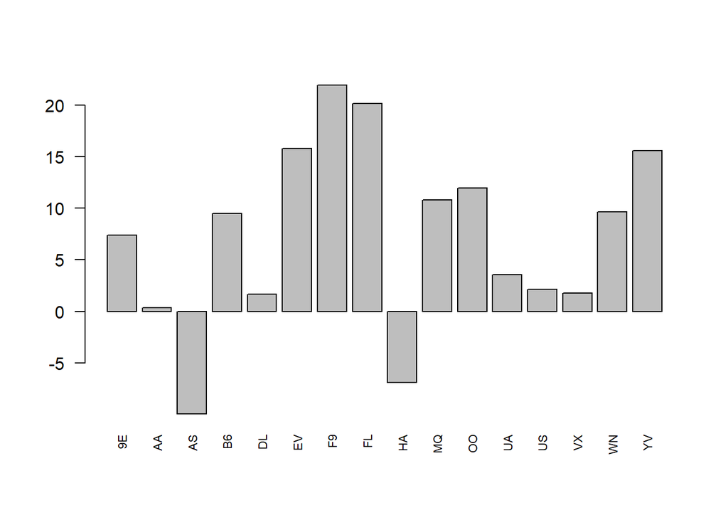

```r
barplot(airline_delay, las=2, cex.names = 0.7)  # las means rotation 90, cex.names changes the Size of name text
```

> Air Gain

calculate airgain values and keep it in a new column

```r
nyc$airgain <- nyc$dep_delay - nyc$arr_delay # creat a new column airgain
summary(nyc$airgain, na.rm=TRUE) # stast summary
```

```
##    Min. 1st Qu.  Median    Mean 3rd Qu.    Max.    NA's
## -196.00   -3.00    7.00    5.66   17.00  109.00    9430
```

```r
airgain_each_carrier <- round(tapply(nyc$airgain, nyc$carrier, mean, na.rm=TRUE), 1) # for each carrier calculate mean of airgain and compare results
airgain_each_carrier
```

```
##   9E   AA   AS   B6   DL   EV   F9   FL   HA   MQ   OO   UA   US   VX   WN   YV
##  9.1  8.2 15.8  3.5  7.6  4.0 -1.7 -1.5 11.8 -0.3  0.7  8.5  1.6 11.0  8.0  3.3
```

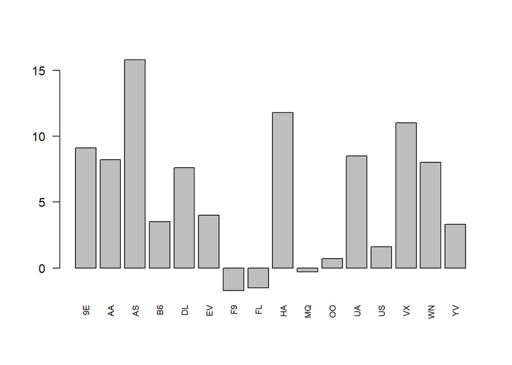

```r
barplot(airgain_each_carrier, las=2, cex.names = 0.7) # plot
```

```r
names(airgain_each_carrier[airgain_each_carrier == max(airgain_each_carrier)]) # filter the name of max mean.
```

```
## [1] "AS"
```